# Factorial experiment example - weight gain

# Problem

(source: Crawley, The R book)

Our example comes from a farm-scale trial of animal diets. There are two factors: diet and supplement.

Diet is a factor with three levels: barley, oats and wheat.

Supplement is a factor with four levels: agrimore, control, supergain and supersupp.

The response variable is weight gain after 6 weeks.

```r
weights <- read.csv("data/growth2.txt", sep="\t")
head(weights)
```

[output not shown]

```r
table(weights$diet, weights$supplement)
```

[output not shown]

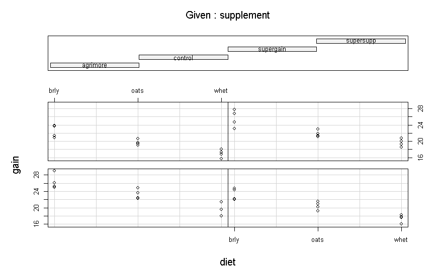

```r
with(weights,
     coplot(gain ~ diet|supplement,rows=2))
```

We will perform an analysis of variance including a factor for the interaction between diet and supplement:

```r
model<-aov(gain~diet*supplement, data = weights)
summary(model)
```

```
                Df Sum Sq Mean Sq F value   Pr(>F)
diet             2 287.17  143.59   83.52 3.00e-14 ***
supplement       3  91.88   30.63   17.82 2.95e-07 ***
diet:supplement  6   3.41    0.57    0.33    0.917
Residuals       36  61.89    1.72
---
Signif. codes:  0 ‘***’ 0.001 ‘**’ 0.01 ‘*’ 0.05 ‘.’ 0.1 ‘ ’ 1
```

The ANOVA table shows that there is no hint of any interaction between the two explanatory variables (p=0.917): the effects of diet and supplement are additive.

Let’s check for this graphically…

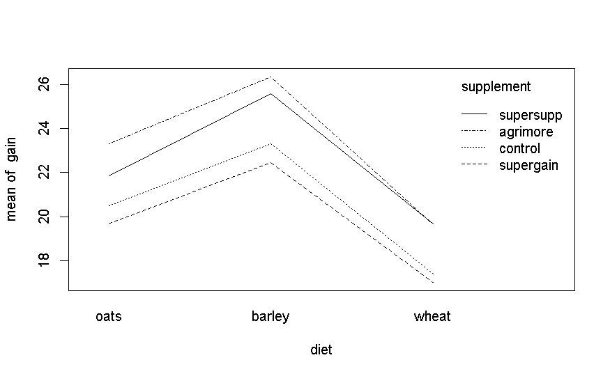

```r
weights$diet <- relevel(weights$diet, ref="oats")
with(weights, interaction.plot(diet,supplement, response = gain))
```

Since interactions are not significant, we can consider simplifying our model:

```r
model2 <- aov(gain~diet + supplement, data = weights)
summary(model2)
```

```
            Df Sum Sq Mean Sq F value   Pr(>F)
diet         2 287.17  143.59   92.36 4.20e-16 ***
supplement   3  91.88   30.63   19.70 3.98e-08 ***
Residuals   42  65.30    1.55
---
Signif. codes:  0 ‘***’ 0.001 ‘**’ 0.01 ‘*’ 0.05 ‘.’ 0.1 ‘ ’ 1
```

Which one is best?

The second model is much simpler than the first one:

```r
summary.lm(model)
```

```
Call:
aov(formula = gain ~ diet * supplement, data = weights)

Residuals:
     Min       1Q   Median       3Q      Max
-2.48756 -1.00368 -0.07452  1.03496  2.68069

Coefficients:
                              Estimate Std. Error t value Pr(>|t|)
(Intercept)                    26.3485     0.6556  40.191  < 2e-16 ***
dietoats                       -3.0501     0.9271  -3.290 0.002248 **
dietwheat                      -6.7094     0.9271  -7.237 1.61e-08 ***
supplementcontrol              -3.0518     0.9271  -3.292 0.002237 **
supplementsupergain            -3.8824     0.9271  -4.187 0.000174 ***
supplementsupersupp            -0.7732     0.9271  -0.834 0.409816
dietoats:supplementcontrol      0.2471     1.3112   0.188 0.851571
dietwheat:supplementcontrol     0.8183     1.3112   0.624 0.536512
dietoats:supplementsupergain    0.2470     1.3112   0.188 0.851652
dietwheat:supplementsupergain   1.2557     1.3112   0.958 0.344601
dietoats:supplementsupersupp   -0.6650     1.3112  -0.507 0.615135
dietwheat:supplementsupersupp   0.8024     1.3112   0.612 0.544381
---
Signif. codes:  0 ‘***’ 0.001 ‘**’ 0.01 ‘*’ 0.05 ‘.’ 0.1 ‘ ’ 1

Residual standard error: 1.311 on 36 degrees of freedom
Multiple R-squared:  0.8607,    Adjusted R-squared:  0.8182
F-statistic: 20.22 on 11 and 36 DF,  p-value: 3.295e-12
```

```r
summary.lm(model2)
```

```
Call:
aov(formula = gain ~ diet + supplement, data = weights)

Residuals:
     Min       1Q   Median       3Q      Max
-2.30792 -0.85929 -0.07713  0.92052  2.90615

Coefficients:
                    Estimate Std. Error t value Pr(>|t|)
(Intercept)          23.0302     0.4408  52.242  < 2e-16 ***
dietbarley            3.0928     0.4408   7.016 1.38e-08 ***
dietwheat            -2.8975     0.4408  -6.573 5.96e-08 ***
supplementcontrol    -2.6967     0.5090  -5.298 4.03e-06 ***
supplementsupergain  -3.3815     0.5090  -6.643 4.72e-08 ***
supplementsupersupp  -0.7274     0.5090  -1.429     0.16
---
Signif. codes:  0 ‘***’ 0.001 ‘**’ 0.01 ‘*’ 0.05 ‘.’ 0.1 ‘ ’ 1

Residual standard error: 1.247 on 42 degrees of freedom
Multiple R-squared:  0.8531,    Adjusted R-squared:  0.8356
F-statistic: 48.76 on 5 and 42 DF,  p-value: < 2.2e-16
```

We can compare them directly:

```r
anova(model,model2)
```

```
Analysis of Variance Table

Model 1: gain ~ diet * supplement
Model 2: gain ~ diet + supplement
  Res.Df    RSS Df Sum of Sq      F Pr(>F)
1     36 61.890
2     42 65.296 -6   -3.4058 0.3302 0.9166
```

The second model is simpler and it is not significantly worst than the first model, so we go for model2 and we try to interpret it.

Go back and look again at the summary of model2:

- the barley and wheat diet are statistically different, in terms of weight gain, from the oats diet, but what about the difference between wheat and barley?
- it’s the same for the control and supergain supplements with respect to agrimore, but what about the difference between them? and with supersupp??

Let’s check with a TukeyHSD test:

```r
TukeyHSD(model2)
```

```
  Tukey multiple comparisons of means
    95% family-wise confidence level

Fit: aov(formula = gain ~ diet + supplement, data = weights)

$diet
                  diff       lwr       upr p adj
barley-oats   3.092817  2.021817  4.163817 0e+00
wheat-oats   -2.897481 -3.968481 -1.826481 2e-07
wheat-barley -5.990298 -7.061298 -4.919297 0e+00

$supplement
                          diff        lwr        upr     p adj
control-agrimore    -2.6967005 -4.0583332 -1.3350677 0.0000234
supergain-agrimore  -3.3814586 -4.7430914 -2.0198259 0.0000003
supersupp-agrimore  -0.7273521 -2.0889849  0.6342806 0.4888738
supergain-control   -0.6847581 -2.0463909  0.6768746 0.5400389
supersupp-control    1.9693484  0.6077156  3.3309811 0.0020484
supersupp-supergain  2.6541065  1.2924737  4.0157392 0.0000307
```

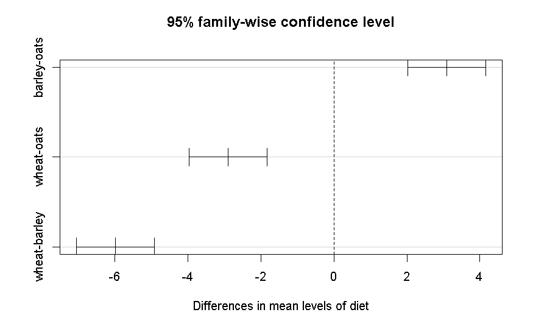

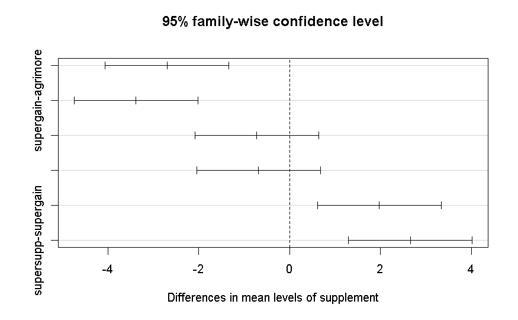

```r
plot(TukeyHSD(model2))
```

Other plots using the jtools package:

```r
# plot_model(model2, type = "diag")
plot_model(model2, type="eff")
```

[output not shown]

check here for an example with a significant interaction: https://cran.r-project.org/web/packages/jtools/vignettes/categorical.html

# Interactions with at least one continuous predictor

(source: https://cran.r-project.org/web/packages/jtools/vignettes/interactions.html)

This famous (Fisher’s or Anderson’s) iris data set gives the measurements in centimeters of the variables sepal length and width and petal length and width, respectively, for 50 flowers from each of 3 species of iris. The species are Iris setosa, versicolor, and virginica.

```r
data(iris)
head(iris)
```

|  | Sepal.Length | Sepal.Width | Petal.Length | Petal.Width | Species |
| --- | --- | --- | --- | --- | --- |
| 1 | 5.1 | 3.5 | 1.4 | 0.2 | setosa |
| 2 | 4.9 | 3.0 | 1.4 | 0.2 | setosa |
| 3 | 4.7 | 3.2 | 1.3 | 0.2 | setosa |
| 4 | 4.6 | 3.1 | 1.5 | 0.2 | setosa |
| 5 | 5.0 | 3.6 | 1.4 | 0.2 | setosa |
| 6 | 5.4 | 3.9 | 1.7 | 0.4 | setosa |

Please note that here we use `lm` rather than `aov`:

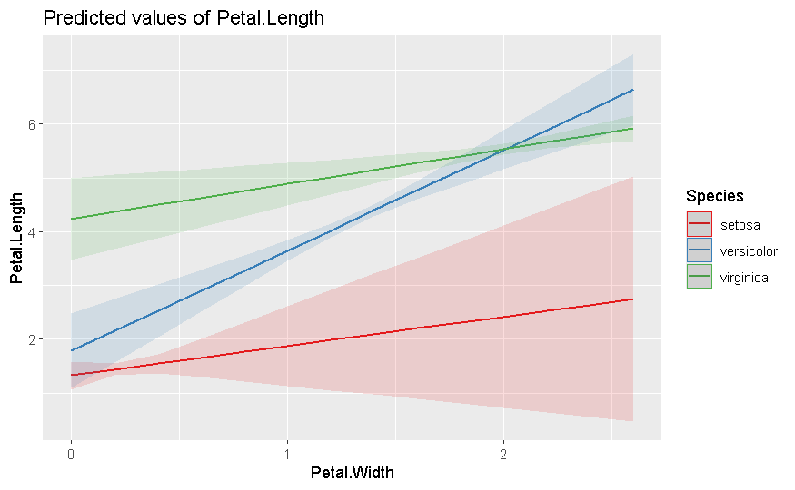

```r
fitiris <- lm(Petal.Length ~ Petal.Width * Species, data = iris)
library(jtools)
plot_model(fitiris, type="int")
```